## HW 5

## Name - Amol Dattatray Sangar

## Assignment Partner - Rishabh Jain

# Problem 1: Pattern-matching: The brute-force

### Problem 1.1: The brute-force pattern-matching algorithm [10 pt.]

Describe a text D and a pattern P such that the brute-force pattern-matching algorithm runs in Ω(dp) time.The lengths of D and P are d and p, respectively.

```python
def find_brute(T, P):
    n, m = len(T), len(P)

    # every starting position
    for i in range(n-m+1):
        k = 0
        # conduct O(k) comparisons
        while k < m and T[i+k] == P[k]:
            k += 1

        if k == m:
            return i

    return -1

text = "abacaabaccabacabaabb"
pattern = "abacab"

startingIndex = find_brute(text,pattern)

if(startingIndex == -1):
    print("Pattern not found in the given string")
else:
    print("Pattern found and the starting index is " + str(startingIndex))
```

```
Pattern found and the starting index is 10
```

###### Explanation -

Here, the brute force pattern matching algorithm runs in O(dp) i.e. worst case. Therefore, the best case is within Ω(dp) time.

### Problem 1.2: Python’s str class and pattern-matching [20 pt]

In this part, you are asked to modify three pattern matching programs given to you (See appendix). Run your modified programs for varying-length patterns and show your results. The count method in Python’s str class takes a text D and a pattern P and returns the maximum number of non-overlapping occurrences of a P within D. As an example ‘cdcdcdcdc’.count(‘cdc’) returns 2.

1. Modify the brute-force pattern-matching to return non-overlapping occurrences of a P within D.
2. Similar to the previous question (Problem 1.2.1), do the same on the Boyer-Moore program.
3. Similar to problem 1.2.1, modify the KMP program.

```python
def find_brute_non_overlapping(T, P):
    n, m = len(T), len(P)

    i = 0
    count = 0
    while i < (n-m+1):
        k = 0

        while k < m and T[i+k] == P[k]:
            k += 1
            if k == m:
                i = i+k-1
                count += 1

        i += 1
    return count

print("Non-overlapping count (Brute Force)", find_brute_non_overlapping('cdcdcdcdc','cdc'))
```

```
Non-overlapping count (Brute Force) 2
```

```python
def find_boyer_moore_non_overlapping(T, P):
    n, m = len(T), len(P)

    if m == 0:
        return 0

    last = {}
    for k in range (m):
        last[P[k]] = k

    count = 0
    i = m -1
    k = m -1
    while i < n:
            # If match , decrease i,k
            if T[i] == P[k]:
                if k == 0:
                    count += 1
                    i += (m * 2) - 1
                    k = m - 1
                else :
                    i -= 1
                    k -= 1
            # Not match , reset the positions
            else :
                j = last.get(T[i], -1)
                #print(j)
                i += m - min(k, j+1)
                k = m -1
    return count

print("Non-overlapping count (Boyer Moore):", find_boyer_moore_non_overlapping('cdcdcdcdc','cdc'))
```

```
Non-overlapping count (Boyer Moore): 2
```

```python
#KMP
def compute_kmp_fail(P):
    m=len(P)
    fail=[0]*m
    j=1
    k=0
    while j < m:
        if P[j]==P[k]:
            fail[j]=k+1
            j+=1
            k+=1
        elif k>0:
            k=fail[k-1]
        else:
            j+=1
    return fail

def find_kmp_non_overlapping(T,P):
    n,m=len(T),len(P)
    if m==0:
        return 0
    fail=compute_kmp_fail(P)

    j=0
    k=0
    count=0
    while j<n:
        if T[j]==P[k]:
            if k==m-1:
                count+=1
                k=k-m
            j+=1
            k+=1
        elif k>0:
            k=fail[k-1]
            j=j-1
        else:
            j+=1
    return count


print("Non-overlapping count (KMP):", find_kmp_non_overlapping('cdcdcdcdc','cdc'))
```

```
Non-overlapping count (KMP): 2
```

# Problem 2: Experimental Analysis of Pattern-Matching Algorithms

```python
import time
import sys
```

```python
def find_brute(T,P):
    n,m=len(T),len(P)
    counter=-1
    for i in range(n-m+1):
        k=0
        while k<m and T[i+k] == P[k]:
            counter+=1
            k+=1
        counter+=1
        if k==m:
            return i,counter
    return -1,counter

def find_boyer_moore(T, P):
    n, m = len(T), len(P)
    counter=0
    if m == 0:
        return 0
    last = {}
    for k in range(m):
        last[P[k]] = k
    i = m-1
    k = m-1
    while i < n:
        counter+=1
        if T[i] == P[k]:
            if k == 0:
                return i,counter
            else:
                i -= 1
                k -= 1
        else:
            j = last.get(T[i], -1)
            i += m - min(k, j+1)
            k = m-1
    return -1,counter

def compute_kmp_fail(P):
    m = len(P)
    fail = [0] * m
    j = 1
    k = 0
    while j < m:
        if P[j] == P[k]:
            fail[j] = k+1
            j += 1
            k += 1
        elif k > 0:
            k = fail[k-1]
        else:
            j += 1
    return fail

def find_kmp(T, P):
    n, m = len(T), len(P)
    counter=0
    if m == 0:
        return 0
    fail = compute_kmp_fail(P)
    j = 0
    k = 0
    while j < n:
        counter+=1
        if T[j] == P[k]:
            if k == m-1:
                return j-m+1,counter
            j += 1
            k += 1
        elif k > 0:
            k = fail[k-1]
        else:
            j += 1
    return -1,counter
```

### Part 1: Number of character comparison

```python
T = "There are dozens of different wiki engines in use, both standalone and part of other software, such as bug tracking systems."
P = "bug"
```

#### Character Comparison Count: Brute Force

```python
result = find_brute(T, P)
print("Index:", result[0])
print("Comparison Count:", result[1])
```

```
Index: 103
Comparison Count: 107
```

#### Character Comparison Count: KMP

```python
index, count = find_kmp(T, P)
print("Index:", index)
print("Comparison Count:", count)
```

```
Index: 103
Comparison Count: 107
```

#### Character Comparison Count: Boyer Moore

```python
index, count = find_boyer_moore(T, P)
print("Index:", index)
print("Comparison Count:", count)
```

```
Index: 103
Comparison Count: 38
```

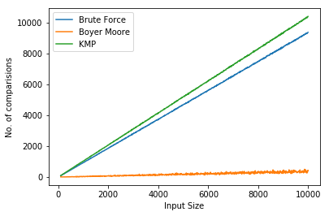

```python
import random
import string
import matplotlib.pyplot as plt

sizes,brute_count,boyer_count,kmp_count=[],[],[],[]
for i in range(10,1000):
    T = ''.join(random.choices(string.ascii_lowercase, k = 10*i))
    P = ''.join(random.choices(string.ascii_lowercase, k = i))

    sizes.append(len(T))

    result1=find_brute(T,P)
    brute_count.append(result1[1])

    result2=find_boyer_moore(T,P)
    boyer_count.append(result2[1])

    result3=find_kmp(T,P)
    kmp_count.append(result3[1])

plt.xlabel('Input Size')
plt.ylabel('No. of comparisions')
plt.plot(sizes, brute_count, label ='Brute Force')
plt.plot(sizes, boyer_count, label ='Boyer Moore')
plt.plot(sizes, kmp_count, label ='KMP')
plt.legend()
plt.show()
```